# Homework 3

YUANJIAN ZHOU

Feb 4,2020

# I Review Question

## 1.

- Expected value and variance of $\bar{Y}$
  $$\begin{align*}
  E(\bar{Y})&=E(\frac{1}{4}\sum_{t=1}^{4}Y_{t})=\frac{1}{4}E(\sum_{t=1}^{4}Y_{t})=\frac{1}{4}*4\mu=\mu\\
  VAR(\bar{Y})&=VAR(\frac{1}{4}\sum_{t=1}^{4}Y_{t})=\frac{1}{16}VAR(\sum_{t=1}^{4}Y_{t})=\frac{1}{16}*4\sigma^2=\frac{1}{4}\sigma^2\\
  \end{align*}$$
- Expected value and variance of W
  $$\begin{align*}
  E(W)&=E(\frac{1}{8}X_1+\frac{1}{8}X_2+\frac{1}{4}X_3+\frac{1}{2} X_4)\\
  &=(\frac{1}{8}+\frac{1}{8}+\frac{1}{4}+\frac{1}{2)}*\mu=\mu\\
  VAR(W)&=VAR(\frac{1}{8}X_1+\frac{1}{8}X_2+\frac{1}{4}X_3+\frac{1}{2} X_4)\\
  &=(\frac{1}{64}+\frac{1}{64}+\frac{1}{16}+\frac{1}{4})*\sigma^2=\frac{11}{32}\sigma^2 \\
  \end{align*}$$
- I prefer $\bar Y$, because W and $\bar Y$ are both unbiased, but $VAR(\bar Y) = \frac{1}{4}\sigma^2<VAR(W)=\frac{11}{32}\sigma^2$

## 2.

- Restriction
  $$\begin{align*}
  E(W_{a})&=E(\sum_{i=1}^{n}\alpha_{i}Y_{i})\\
  &=\sum_{i=1}^{n}\alpha_{i}*E(Y_{i})=\sum_{i=1}^{n}\alpha_{i}\mu\\
  \end{align*}$$
- In order to make $W_{a}$ a unbiased estimator of $\mu$, we need $\sum_{i=1}^{n}\alpha_{i}=1$.
- $VAR(W_{\alpha})$
  $$\begin{align*}
  VAR(W_{\alpha})&=VAR(\sum_{i=1}^{n}\alpha_{i}Y_{i})=\sum_{i=1}^{n}\alpha_{i}^{2}VAR(Y_{i})=\sum_{i=1}^{n}\alpha_{i}^{2} \sigma^2\\
  \end{align*}$$
- We want to show that $\bar Y$ is the BLUE estimaor.
1. Linear
- Let the $\alpha_{i}$ in the class of linear estimator = $\frac{1}{n}$, we can get that $\bar Y$ belongs to the linear estimator.
2. Unbiased
   $$\begin{align*}
   E(\bar{Y})&=E(\frac{1}{n}\sum_{i=1}^{n}Y_{i})=\frac{1}{n}E(\sum_{i=1}^{n}Y_{i})=\frac{1}{n}*n\mu=\mu\\
   \end{align*}$$
3. Best(Efficient)

$$\begin{align*}
VAR(\bar{Y})&=VAR(\frac{1}{n}\sum_{i=1}^{n}Y_{i})=\frac{1}{n^2}VAR(\sum_{i=1}^{n}Y_{i})=\frac{1}{n^2}*n\sigma^2=\frac{1}{n}\sigma^2\\
VAR(W_{\alpha})&=\sum_{i=1}^{n}\alpha_{i}^{2} \sigma^2\\
\text{We restrict that} \sum_{i=1}^{n}\alpha_{i}&=1, \text{hence}\\
VAR(\bar{Y})-VAR(W_{\alpha})&=\sigma^2(\frac{1}{n}-\sum_{i=1}^{n}\alpha_{i}^{2})
\end{align*}$$

- From the inequality, we know that $1\leq n\sum_{i=1}^{n}\alpha_{i}^{2}$, so $\frac{1}{n}\leq\sum_{i=1}^{n}\alpha_{i}^{2}$, hence $VAR(\bar{Y})\leq VAR(W_{\alpha})$
- In all, $\bar Y$ is the BLUE estimator.

## 3

- 95% C.I for $\mu_{i},\sigma^2_{i}$
  $$\begin{align*}
  {C.I({\mu_1})} &= \hat{\mu_1} \pm\frac{\hat{\sigma_1}}{\sqrt{T}} * 1.96\\
  &= 0.01 \pm\frac{0.1}{\sqrt{100}} * 1.96 = [-0.0096,0.0296]\\
  {C.I({\mu_2})} &= \hat{\mu_2} \pm\frac{\hat{\sigma_2}}{\sqrt{T}} * 1.96\\
  &= -0.03 \pm\frac{0.3}{\sqrt{100}} * 1.96 = [-0.0888,0.0288]\\
  {C.I({\sigma^2_1})} &= \hat{\sigma_1}^2 \pm\frac{\sqrt{2}\hat{\sigma_1}^2}{\sqrt{T}} * 1.96\\
  &= 0.1^2 \pm\frac{\sqrt{2}*0.01}{\sqrt{100}} * 1.96 = [0.007,0.013]\\
  {C.I({\sigma^2_2})} &= \hat{\sigma_2}^2 \pm\frac{\sqrt{2}\hat{\sigma_2}^2}{\sqrt{T}}* 1.96\\
  &= 0.3^2 \pm\frac{\sqrt{2}*0.09}{\sqrt{100}}* 1.96 = [0.065,0.115]
  \end{align*}$$
- 95% C.I for $\rho_{12}$

$$\begin{align*}
{C.I({\rho_{12}})} &= \hat{\rho_{12}} \pm\frac{1- \hat{\rho_{12}}^2}{\sqrt{T}} * 1.96\\
&= 0.4 \pm\frac{1-0.16}{\sqrt{100}} * 1.96 = [0.235,0.565]
\end{align*}$$

- Hypothesis test for $\mu$
  $$\begin{align*}
  H_0: \mu_{i} &= 0 \ vs \ H_1: \mu_{i} \neq 0\\
  t_1 &= \frac{0.01-0}{\frac{0.1}{\sqrt{100}}} = 1 <t_c=t_{0.95} = 1.96\\
  |t_2| &= \frac{-0.03-0}{\frac{0.3}{\sqrt{100}}} = |-1|=1 <t_c=t_{0.95}
  = 1.96
  \end{align*}$$
- So we can not reject $H_{0}$ for both 1 and 2, expected returns of these assets are not statisitically different from 0.
- Hypothesis test for $\sigma^2$
  $$\begin{align*}
  H_0: \sigma^2_{i} &= 0.0225 \ vs \ H_1: \sigma^2_{i} \neq 0.0225\\
  |t_1| &= \frac{0.01-0.0225}{\frac{\sqrt{2}*0.01}{\sqrt{100}}} = |-8.84|=8.84 >t_c=t_{0.95} = 1.96\\
  t_2 &= \frac{0.09-0.0225}{\frac{\sqrt{2}*0.09}{\sqrt{100}}} =5.30 >t_c=t_{0.95}
  = 1.96
  \end{align*}$$
- We reject $H_{0}$ for both 1 and 2.

# II R Exercise

## 1

### (a)

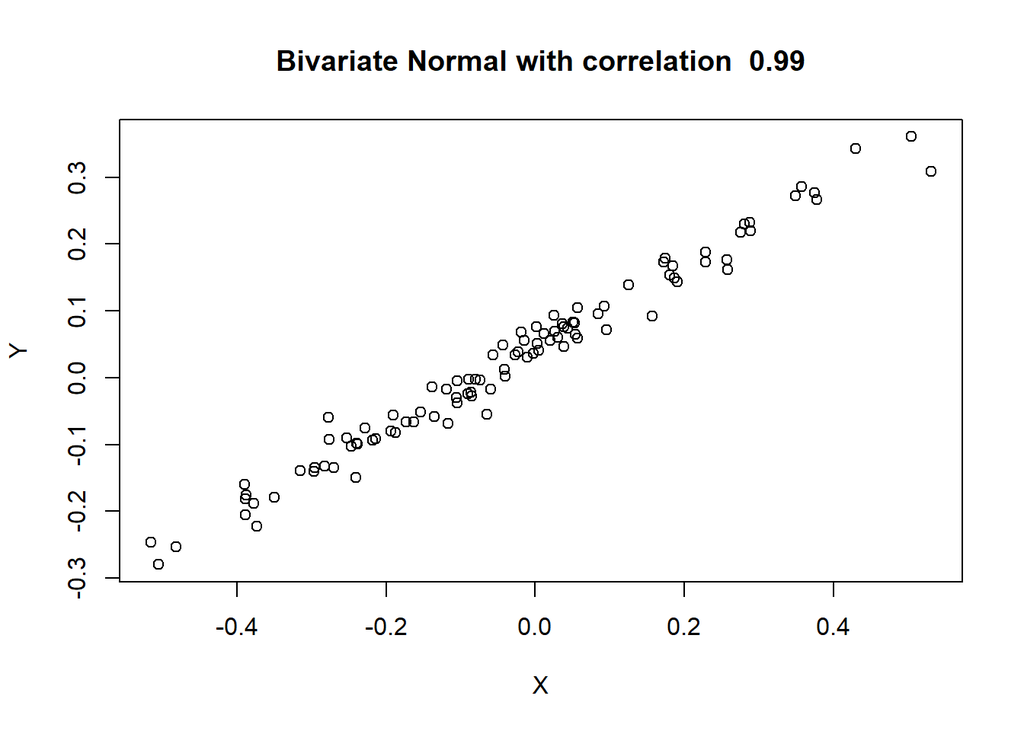

```
## [1] "joint probability P(X<=0,Y<=0)=0.369"
```

```r
exercise = function(p){
cov = p * 0.25 * 0.15
covm = matrix(c(0.0625, cov, cov, 0.0225), ncol = 2, byrow = T)
a = rmvnorm(100, mean = c(0.01, 0.05), sigma = covm)
plot(a, xlab = "X", ylab = "Y", main = (paste("Bivariate Normal with correlation ", p)))
p = pmvnorm(lower = c(-Inf, -Inf), upper = c(0,0), mean = c(0.01,0.05), sigma = covm)
sprintf("joint probability P(X<=0,Y<=0)=%#.3f", p)
}
exercise(0.99)
```

- It has a positive strong linear association

### (b)

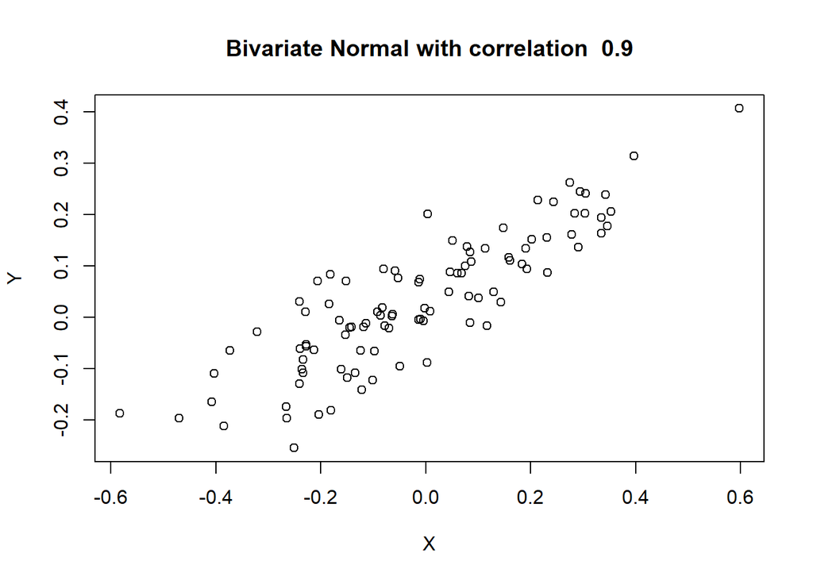

```
## [1] "joint probability P(X<=0,Y<=0)=0.342"
```

```r
exercise(0.9)
```

- It has a positive strong linear association, weaker than when $\rho = 0.99$.

### (c)

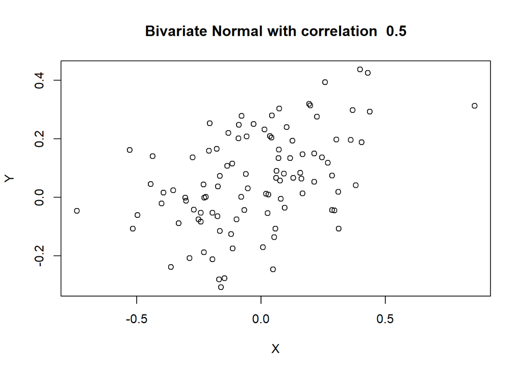

```
## [1] "joint probability P(X<=0,Y<=0)=0.257"
```

```r
exercise(0.5)
```

- It has a positive not so strong linear association, weaker than when $\rho = 0.9$.

### (d)

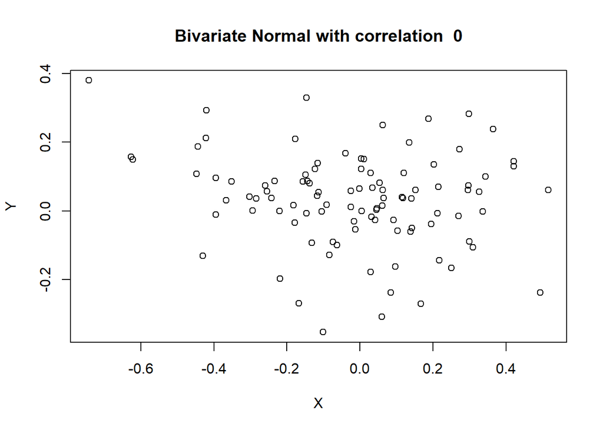

```
## [1] "joint probability P(X<=0,Y<=0)=0.179"
```

```r
exercise(0)
```

- It has no linear association.

### (e)

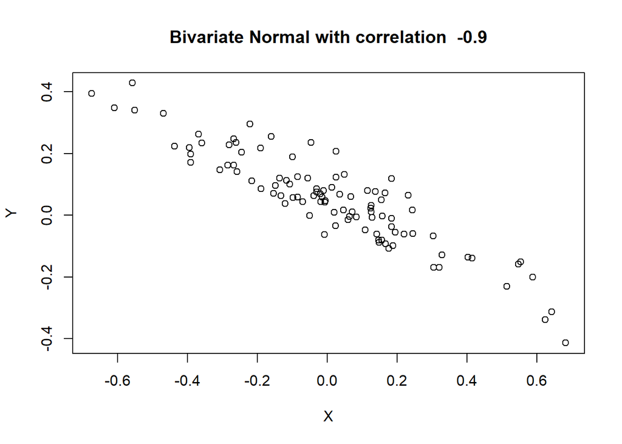

```
## [1] "joint probability P(X<=0,Y<=0)=0.020"
```

```r
exercise(-0.9)
```

- It has a negative strong linear association, weaker than when $\rho = 0.99$.

## 2

### (a)

```r
atleast = rep(0, 100000) # numbers of trials
set.seed(46)
for (i in 1:100000) {
  r <- rnorm(45, mean = .05 / 253,
             sd = .23 / sqrt(253))
  W <- 1e6 * exp(cumsum(r)) # wealth for each day
  atleast[i] <- any(W <= 950000) # check
}
sprintf("the probability that the value of the stock will be below $950,000 at the close of at least one of the next 45 trading days is %#.3f", mean(atleast))
```

```
## [1] "the probability that the value of the stock will be below $950,000 at the close of at least one of the next 45 trading days is 0.508"
```

### (b)

```r
bigprofit =rep(0,100000)
set.seed(46)
for (i in 1 : 100000) {
  r <- rnorm(45, mean = .05 / 253,
             sd = .23/ sqrt(253))
  W <- 1e6 * exp(cumsum(r))
  bigprofit[i] <- ifelse(as.numeric(any(W <= 950000)) == 1, 0, W[45])
}
sprintf("the probability that the hedge fund will make a prot of at least $100,000 is %#.4f", mean(bigprofit > 1.1e6))
```

```
## [1] "the probability that the hedge fund will make a prot of at least $100,000 is 0.1714"
```

### (c)

```r
#c
loss <- rep(0, 100000)
wipe <- rep(0, 100000)
loss_atend <- rep(0,100000)
for (i in 1:100000) {
  r <- rnorm(45, mean = .05 / 253,
             sd = .23/ sqrt(253))
  W <- 1e6 * exp(cumsum(r))
  wipe[i] <- any(W <= 950000) # wipe out
  loss_atend[i] <- (W[45] < 1e6) # at day 45 W is less than 950000
  loss[i] <- wipe[i] | loss_atend[i]
}
sprintf("the probability the hedge fund will suffer a loss is %#.3f",mean(loss)
)
```

```
## [1] "the probability the hedge fund will suffer a loss is 0.579"
```

### (d)

```r
Profit <- rep(0, 100000)
Price <- rep(0, 100000)
wipe_point <- rep(0, 100000)
set.seed(46)
for (i in 1 : 100000) {
  r <- rnorm(45, mean = .05 / 253,
             sd = .23/ sqrt(253))
  W <- 1e6 * exp(cumsum(r))
    if(any(W <= 950000) == 1){
    wipe_point[i] <- which(W <= 950000)[1] # if wipe out, find the date of wipping out
    Price[i] <- W[wipe_point[i]]
  }
  else {
    Price[i] <- W[45] # if not wipe out, wealth on day 45
  }
}

Profit <- Price - 950000 - 50000 # profit = price - cost - borrow
sprintf("the expected profit from this trading strategy is %#3.f", mean(Profit))
```

```
## [1] "the expected profit from this trading strategy is 9692."
```

### (e)

```r
cc_mean <- rep(0, 100000)
wipe_point2 <- rep(0, 100000)
simple_return <- rep(0, 100000)
for (i in 1 : 100000) {
  r <- rnorm(45, mean = .05 / 253,
             sd = .23/ sqrt(253))
  r_cumsum <- cumsum(r)
  if(any(r_cumsum <= -0.05) == 1){ # wipe out
    wipe_point2[i] <- which(r_cumsum <= -0.05)[1] # the day where wipe out
    simple_return[i] <- (exp(r_cumsum[wipe_point2[i]]) * 1e6 - 1e6) / 50000 # calculate simple return of 45 days
    if((wipe_point2[i] != 0) & (simple_return[i] >= -1)){ # loss does not go over 50000
      cc_mean[i] <- log(1 + simple_return[i]) / wipe_point2[i]
    }
    else if((wipe_point2[i] != 0) & (simple_return[i] < -1)) # loss go over 50000
      cc_mean[i] <- -log(abs((exp(r_cumsum[wipe_point2[i]]) * 1e6 - 1e6) / 50000)) / wipe_point2[i]

    # if wipe out the average return is the average between day 1 and the day that wipe out
  }
  else {
    simple_return[i] <- (exp(r_cumsum[45]) * 1e6 - 1e6) / 50000
    cc_mean[i] <- log(1 + simple_return[i]) / 45
# if not, the average return is the aeverage over 45 days
  }
}
sprintf("the expected averaging return is %#.3f", mean(cc_mean))
```

```
## [1] "the expected averaging return is -0.030"
```